# Assignment 3 Lizard sprint ticks

Molly Richard

```r
library(ggplot2)
library(dplyr)
library(arm)
library(MASS)
library(ggfortify)
library(readr)
library(emmeans)

lizard <- read_csv("lizard_sprint_tick.csv")
```

**QUESTION 1**: 1. Is there a relationship between hind limb length (HLL) and sprint performance (Max_25cm or Max_2m)? Is this better described by a traditional linear model (OLS) or by a GLM with some other specified error and ‘link’ functions?

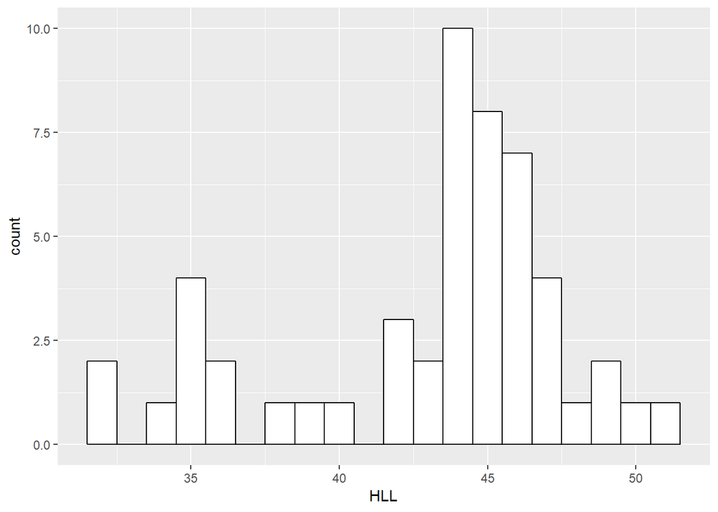

```r
ggplot(lizard, aes(x=HLL)) + geom_histogram(binwidth=1, colour="black", fill="white")
```

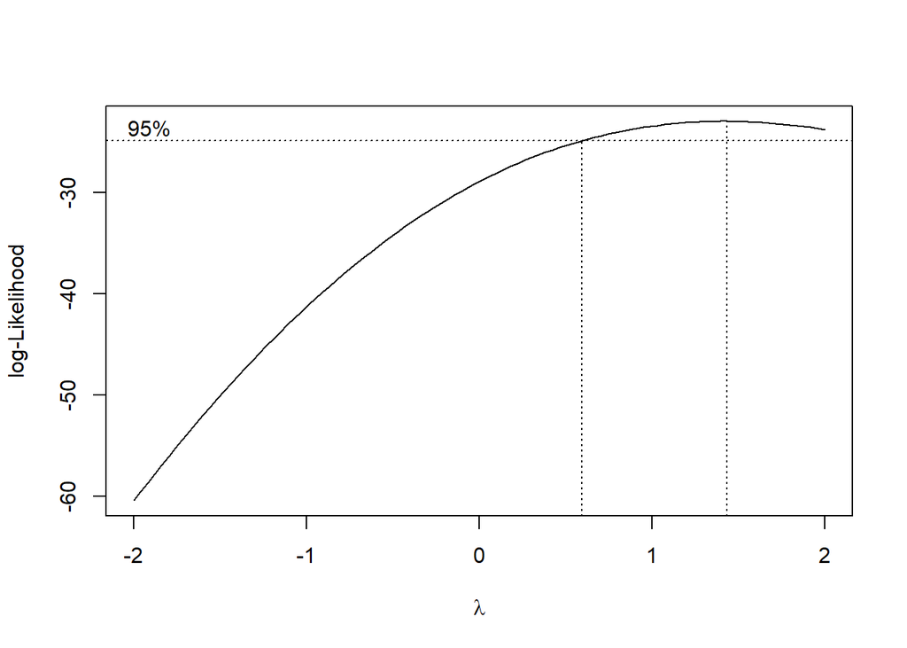

```r
boxcox(glm(Max_2m ~ HLL, data = lizard))
```

Based on the histogram, the data are not normally distibuted leading me to suspect a poisson would be the better choice.

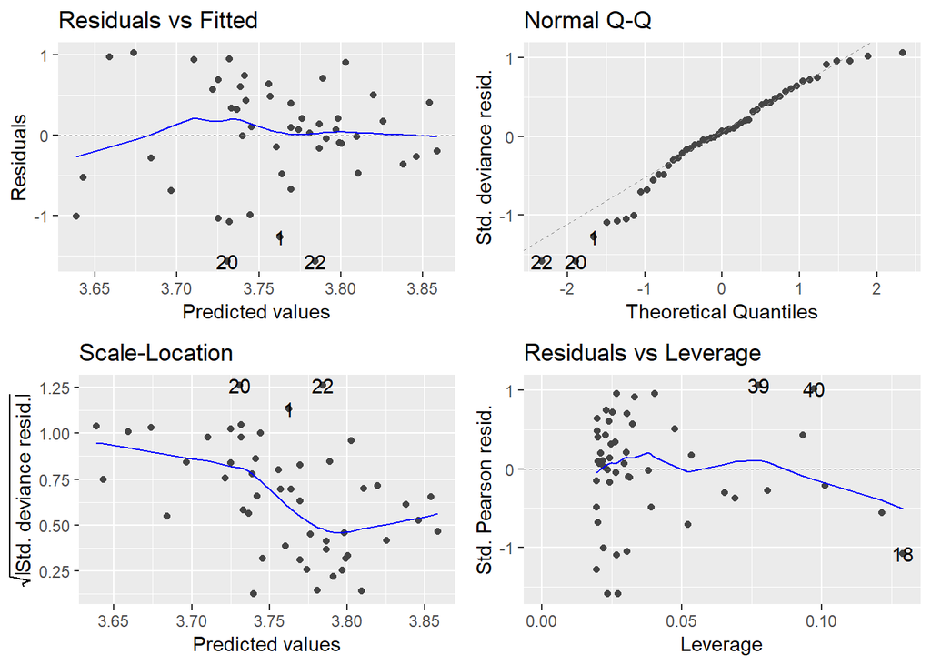

```r
lizardpois <- glm(HLL ~ Max_2m, data = lizard, family = poisson(link = log))
autoplot(lizardpois)
```

```r
summary(lizardpois)
```

```
##
## Call:
## glm(formula = HLL ~ Max_2m, family = poisson(link = log), data = lizard)
##
## Deviance Residuals:
##      Min        1Q    Median        3Q       Max
## -1.57304  -0.32519   0.06418   0.45311   1.02333
##
## Coefficients:
##             Estimate Std. Error z value Pr(>|z|)
## (Intercept)  3.55408    0.09316  38.150   <2e-16 ***
## Max_2m       0.11409    0.04933   2.313   0.0207 *
## ---
## Signif. codes:  0 '***' 0.001 '**' 0.01 '*' 0.05 '.' 0.1 ' ' 1
##
## (Dispersion parameter for poisson family taken to be 1)
##
##     Null deviance: 26.745  on 50  degrees of freedom
## Residual deviance: 21.361  on 49  degrees of freedom
## AIC: 310.86
##
## Number of Fisher Scoring iterations: 4
```

```r
coef(lizardpois)
```

```
## (Intercept)      Max_2m
##   3.5540785   0.1140851
```

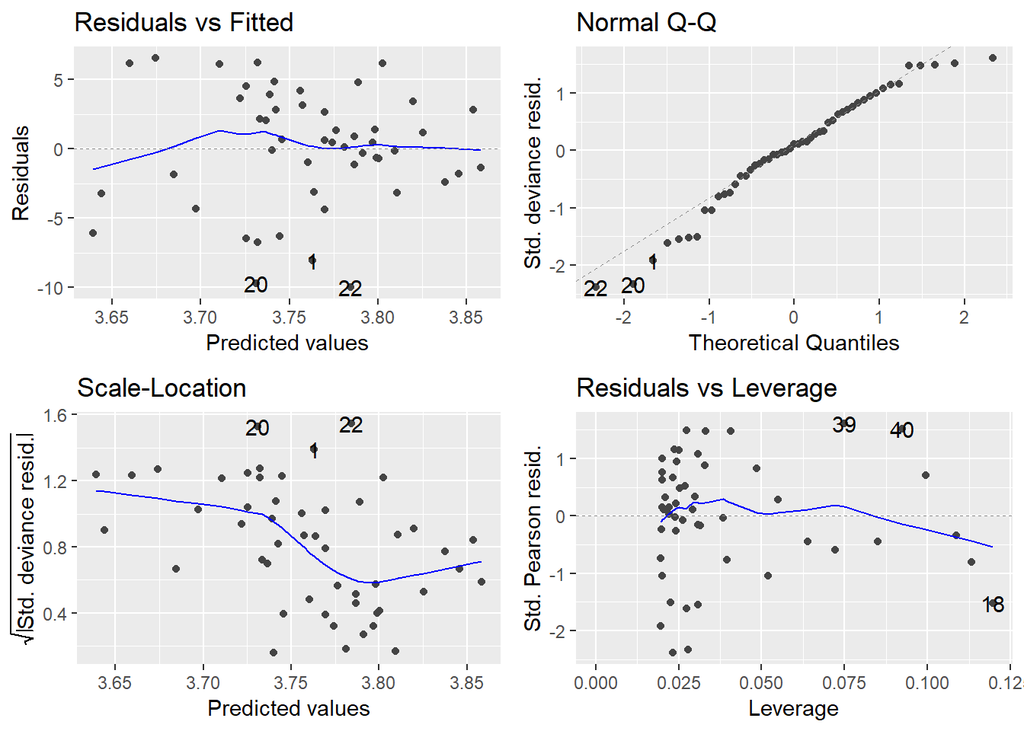

```r
lizardgaus <- glm(HLL ~ Max_2m, data = lizard, family = gaussian(link = log))
autoplot(lizardgaus)
```

```r
summary(lizardgaus)
```

```
##
## Call:
## glm(formula = HLL ~ Max_2m, family = gaussian(link = log), data = lizard)
##
## Deviance Residuals:
##      Min        1Q    Median        3Q       Max
## -10.0101   -2.1246    0.4369    3.0042    6.5757
##
## Coefficients:
##             Estimate Std. Error t value Pr(>|t|)
## (Intercept)  3.55527    0.06130  57.996  < 2e-16 ***
## Max_2m       0.11344    0.03213   3.531 0.000914 ***
## ---
## Signif. codes:  0 '***' 0.001 '**' 0.01 '*' 0.05 '.' 0.1 ' ' 1
##
## (Dispersion parameter for gaussian family taken to be 17.9506)
##
##     Null deviance: 1108.82  on 50  degrees of freedom
## Residual deviance:  879.58  on 49  degrees of freedom
## AIC: 295.96
##
## Number of Fisher Scoring iterations: 4
```

```r
coef(lizardgaus)
```

```
## (Intercept)      Max_2m
##   3.5552680   0.1134416
```

The deviances are much lower on the poisson model (null = 26.745, residual = 21.361) compared to the gaussian model (null = 1108.82, residual = 879.58) taking me to my next step in comparing the poisson to a quasipoisson model.

```r
lizardqpois <- glm(HLL ~ Max_2m, quasipoisson, data= lizard)
summary(lizardqpois)
```

```
##
## Call:
## glm(formula = HLL ~ Max_2m, family = quasipoisson, data = lizard)
##
## Deviance Residuals:
##      Min        1Q    Median        3Q       Max
## -1.57304  -0.32519   0.06418   0.45311   1.02333
##
## Coefficients:
##             Estimate Std. Error t value Pr(>|t|)
## (Intercept)  3.55408    0.06087  58.386  < 2e-16 ***
## Max_2m       0.11409    0.03223   3.539  0.00089 ***
## ---
## Signif. codes:  0 '***' 0.001 '**' 0.01 '*' 0.05 '.' 0.1 ' ' 1
##
## (Dispersion parameter for quasipoisson family taken to be 0.4269318)
##
##     Null deviance: 26.745  on 50  degrees of freedom
## Residual deviance: 21.361  on 49  degrees of freedom
## AIC: NA
##
## Number of Fisher Scoring iterations: 4
```

```r
coef(lizardqpois)
```

```
## (Intercept)      Max_2m
##   3.5540785   0.1140851
```

```r
confint(lizardqpois)
```

```
##                  2.5 %    97.5 %
## (Intercept) 3.43420724 3.6728210
## Max_2m      0.05102472 0.1773798
```

Next step is to compare the summary statistic to find the lower standard errors between a poisson model and a quasipoisson model. The quasipoisson model had lower standard errors (x=0.06087, 0.032230) compared to the poisson model (x=0.09316, 0.04933) leading me to choose the quasipoisson as the best model choice for this data set.

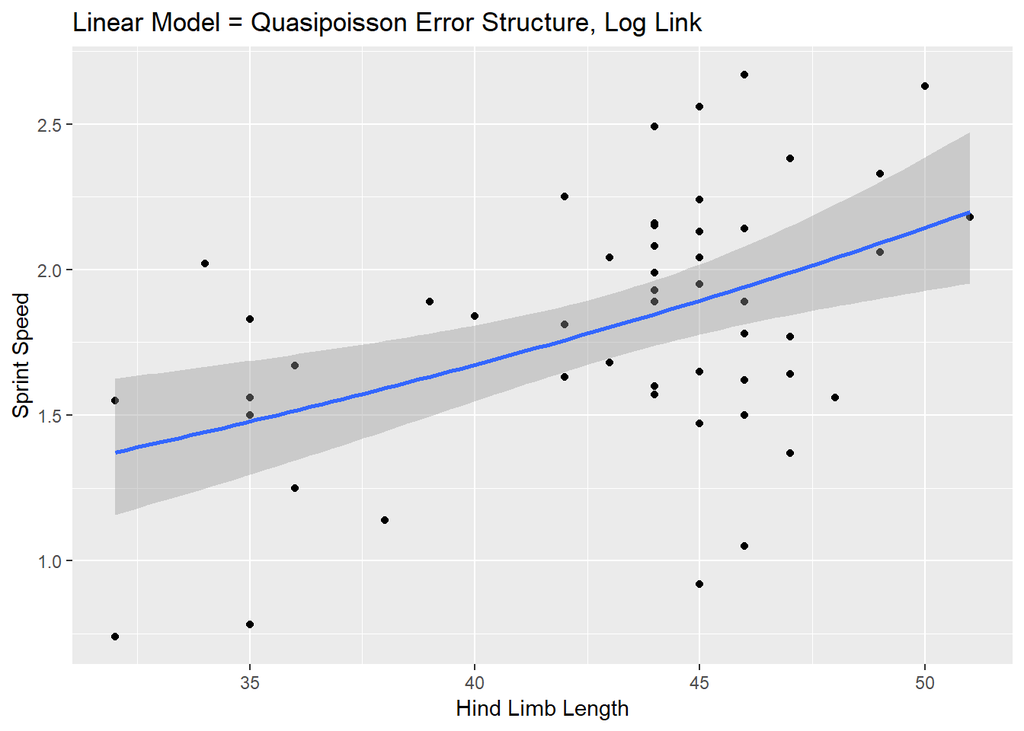

```r
ggplot(lizard, aes(x = HLL , y = Max_2m)) +
geom_point() +
geom_smooth(method="glm", method.args=list(family="quasipoisson"(link="log"))) +
xlab("Hind Limb Length") + ylab("Sprint Speed") +
  ggtitle("Linear Model = Quasipoisson Error Structure, Log Link")
```

The linear model graph shows a positive relationship between hind limb length and spring speed at 2 meters, and is further supports by the intercept (3.554), slope (0.114), and confidence intervals not containing zero.

**QUESTION 2**: 2. Does level of parasitism (#ticks) modify the relationship between hind limb length (HLL) and sprint performance (Max_25cm or Max_2m)?

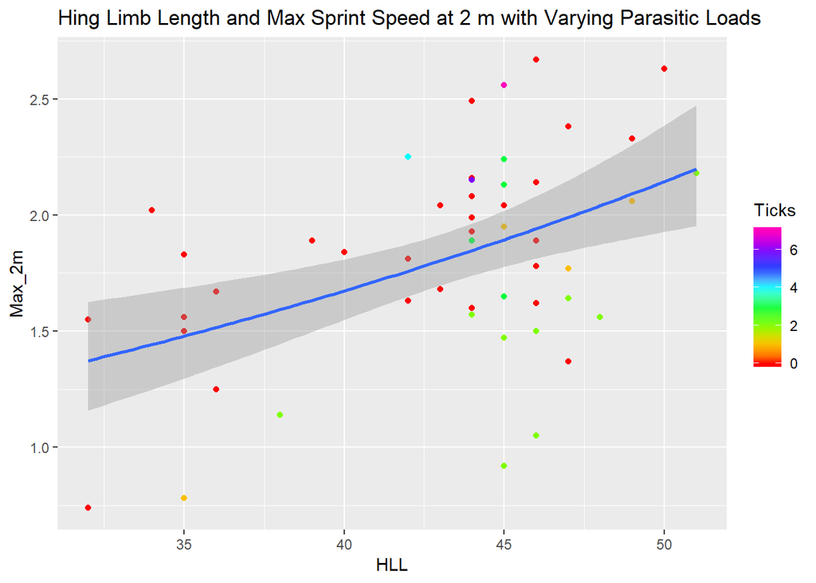

```r
ggplot(lizard, aes(x=HLL, y=Max_2m, colour = Ticks))+
  #scale_color_gradient()+
  geom_point()+
  scale_colour_gradientn(colours=rainbow(8))+
  geom_smooth(method="glm",method.args=list(family="quasipoisson"(link="log")))+
  ggtitle("Hing Limb Length and Max Sprint Speed at 2 m with Varying Parasitic Loads")
```

```r
ticksglm <- (glm(Max_2m ~ HLL + Ticks + HLL:Ticks, family = quasipoisson(link = log), data= lizard))
summary(ticksglm)
```

```
##
## Call:
## glm(formula = Max_2m ~ HLL + Ticks + HLL:Ticks, family = quasipoisson(link = log),
##     data = lizard)
##
## Deviance Residuals:
##      Min        1Q    Median        3Q       Max
## -0.78691  -0.20042   0.03954   0.17117   0.49126
##
## Coefficients:
##              Estimate Std. Error t value Pr(>|t|)
## (Intercept) -0.504068   0.354343  -1.423  0.16147
## HLL          0.025427   0.008224   3.092  0.00334 **
## Ticks        0.075739   0.431923   0.175  0.86156
## HLL:Ticks   -0.001700   0.009729  -0.175  0.86202
## ---
## Signif. codes:  0 '***' 0.001 '**' 0.01 '*' 0.05 '.' 0.1 ' ' 1
##
## (Dispersion parameter for quasipoisson family taken to be 0.0917878)
##
##     Null deviance: 5.7348  on 50  degrees of freedom
## Residual deviance: 4.5798  on 47  degrees of freedom
## AIC: NA
##
## Number of Fisher Scoring iterations: 4
```

```r
coef(ticksglm)
```

```
##  (Intercept)          HLL        Ticks    HLL:Ticks
## -0.504067922  0.025427161  0.075738805 -0.001700255
```

Based on the coefficients from the summary table, the level of parasitism does not affect the relationship between sprint speed and hind limb length (p=0.862).

**QUESTION 3**: Is sprint speed different between treatments after accounting for both hind limb length (HLL) AND level of parasitism (#ticks)? (hint: use library(emmeans) for pairwise comparisons of covariate-adjusted means)

```r
siteglm <- (glm(Max_2m ~ HLL * Ticks + Site, family = quasipoisson(link = log), data= lizard))
emsite <- emmeans(siteglm, ~Site:HLL)
pairs(emsite)
```

```
##  contrast                                                estimate
##  Control,43.0588235294118 - New Burn,43.0588235294118  -0.1901081
##  Control,43.0588235294118 - Recovery,43.0588235294118   0.0075879
##  New Burn,43.0588235294118 - Recovery,43.0588235294118  0.1976960
##          SE  df z.ratio p.value
##  0.08523519 Inf  -2.230  0.0662
##  0.07623024 Inf   0.100  0.9946
##  0.08209254 Inf   2.408  0.0424
##
## Results are given on the log (not the response) scale.
## P value adjustment: tukey method for comparing a family of 3 estimates
```

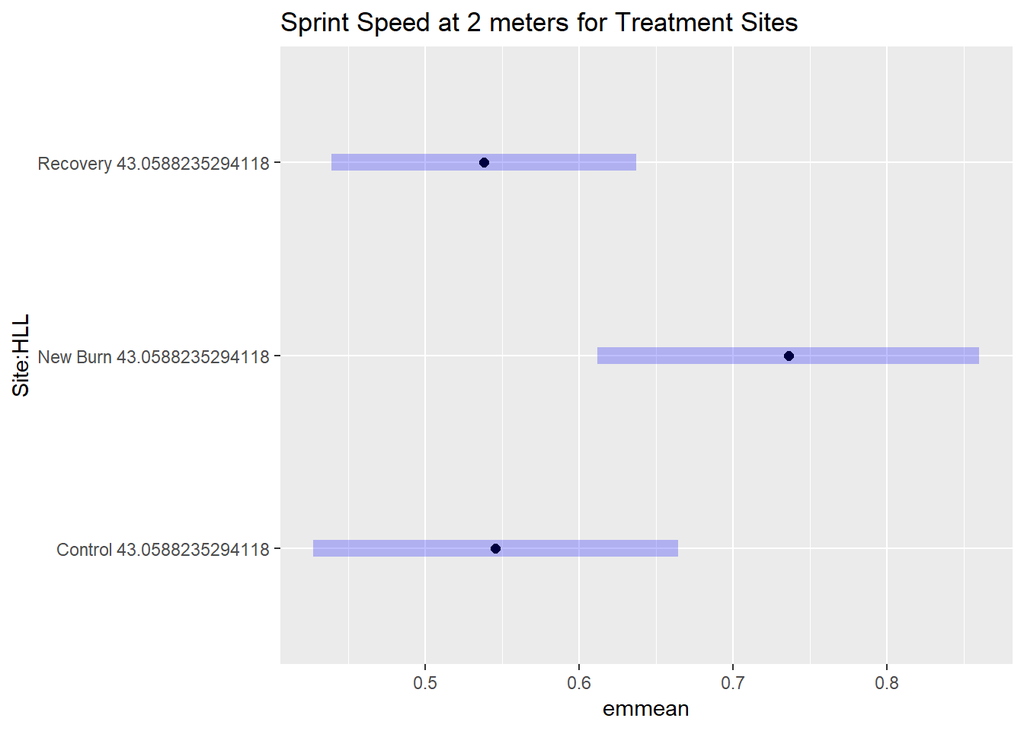

```r
plot(emsite)+
  ggtitle("Sprint Speed at 2 meters for Treatment Sites")
```

Sprint speed at 2 meters is significantly different between the new burn and recovery sites (p=0.042). Sprint speed at 2 meters was also marginally signficant between the control and new burn sites (p=0.066). Biologically this may be worth looking into further as classmates found the 25 cm sprint speed was significant between the control and new burn sites (p=0.0177). Sprint speed at 2 meters was not significantly different from control and recovery sites (p=0.995).